# Reflection 02 (Class 6): ML Pipeline, Error Analysis, and Overfitting

Author

Muhammad Al Hasib

## First ML Pipeline: Predicting Vote Choice with TEDS 2016

The following ML pipeline uses the TEDS 2016 dataset to predict vote choice for Tsai Ing-wen using logistic regression, a decision tree, and a random forest. The pipeline covers data preparation, model training, evaluation, and error analysis.

### Setup

```r
library(haven)
library(tidyverse)
library(caret)
library(rpart)
library(rpart.plot)
library(randomForest)
```

### Load and Prepare Data

```r
TEDS_2016 <- read_stata("https://github.com/datageneration/home/blob/master/DataProgramming/data/TEDS_2016.dta?raw=true")

teds <- TEDS_2016 %>%
  mutate(
    vote = factor(votetsai, levels = c(0, 1), labels = c("Other", "Tsai")),
    gender = factor(female, levels = c(0, 1), labels = c("Male", "Female"))
  ) %>%
  dplyr::select(vote, gender, age, edu, income, Taiwanese, Econ_worse, DPP) %>%
  drop_na()

glimpse(teds)
```

```
Rows: 1,257
Columns: 8
$ vote       <fct> Tsai, Other, Tsai, Tsai, Tsai, Tsai, Tsai, Tsai, Other, Oth…
$ gender     <fct> Female, Male, Female, Male, Female, Female, Male, Female, F…
$ age        <dbl> 39, 63, 64, 75, 54, 64, 66, 25, 41, 57, 83, 43, 44, 34, 28,…
$ edu        <dbl> 5, 5, 2, 1, 5, 1, 1, 2, 5, 5, 1, 5, 5, 3, 3, 3, 3, 1, 5, 3,…
$ income     <dbl> 7.0, 8.0, 9.0, 1.0, 10.0, 2.0, 3.0, 5.5, 9.0, 1.0, 5.5, 5.0…
$ Taiwanese  <dbl> 0, 0, 1, 0, 1, 1, 1, 1, 1, 0, 0, 1, 1, 1, 0, 0, 0, 0, 0, 1,…
$ Econ_worse <dbl> 0, 1, 1, 1, 1, 1, 1, 0, 0, 1, 0, 1, 1, 0, 0, 0, 1, 0, 1, 0,…
$ DPP        <dbl> 0, 0, 1, 0, 0, 0, 1, 1, 0, 0, 0, 0, 1, 0, 0, 0, 0, 0, 0, 1,…
```

### Train-Test Split

```r
set.seed(6323)
train_index <- createDataPartition(teds$vote, p = 0.7, list = FALSE)
train_data <- teds[train_index, ]
test_data  <- teds[-train_index, ]

cat("Training set:", nrow(train_data), "observations\n")
```

```
Training set: 880 observations
```

```r
cat("Test set:", nrow(test_data), "observations\n")
```

```
Test set: 377 observations
```

### Model 1: Logistic Regression

```r
logit_model <- glm(vote ~ age + gender + edu + income + Taiwanese + Econ_worse + DPP,
                   data = train_data,
                   family = binomial)

logit_probs <- predict(logit_model, newdata = test_data, type = "response")
logit_pred  <- factor(ifelse(logit_probs > 0.5, "Tsai", "Other"), levels = c("Other", "Tsai"))

cm_logit <- confusionMatrix(logit_pred, test_data$vote)
cm_logit
```

```
Confusion Matrix and Statistics

          Reference
Prediction Other Tsai
     Other   104   40
     Tsai     37  196

               Accuracy : 0.7958
                 95% CI : (0.7515, 0.8353)
    No Information Rate : 0.626
    P-Value [Acc > NIR] : 8.186e-13

                  Kappa : 0.5657

 Mcnemar's Test P-Value : 0.8197

            Sensitivity : 0.7376
            Specificity : 0.8305
         Pos Pred Value : 0.7222
         Neg Pred Value : 0.8412
             Prevalence : 0.3740
         Detection Rate : 0.2759
   Detection Prevalence : 0.3820
      Balanced Accuracy : 0.7840

       'Positive' Class : Other
```

### Model 2: Decision Tree

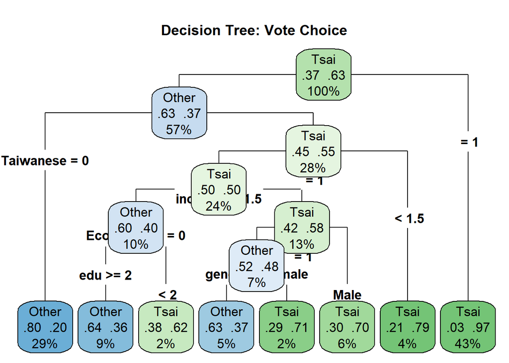

```r
tree_model <- rpart(vote ~ age + gender + edu + income + Taiwanese + Econ_worse + DPP,
                    data = train_data, method = "class")

rpart.plot(tree_model, type = 4, extra = 104,
           main = "Decision Tree: Vote Choice",
           box.palette = "BuGn", cex = 1.1)
```

```r
tree_pred <- predict(tree_model, newdata = test_data, type = "class")
cm_tree <- confusionMatrix(tree_pred, test_data$vote)
cm_tree
```

```
Confusion Matrix and Statistics

          Reference
Prediction Other Tsai
     Other   118   54
     Tsai     23  182

               Accuracy : 0.7958
                 95% CI : (0.7515, 0.8353)
    No Information Rate : 0.626
    P-Value [Acc > NIR] : 8.186e-13

                  Kappa : 0.5823

 Mcnemar's Test P-Value : 0.0006289

            Sensitivity : 0.8369
            Specificity : 0.7712
         Pos Pred Value : 0.6860
         Neg Pred Value : 0.8878
             Prevalence : 0.3740
         Detection Rate : 0.3130
   Detection Prevalence : 0.4562
      Balanced Accuracy : 0.8040

       'Positive' Class : Other
```

### Model 3: Random Forest

```r
set.seed(6323)
rf_model <- randomForest(vote ~ age + gender + edu + income + Taiwanese + Econ_worse + DPP,
                         data = train_data, ntree = 500, importance = TRUE)

rf_pred <- predict(rf_model, newdata = test_data)
cm_rf <- confusionMatrix(rf_pred, test_data$vote)
cm_rf
```

```
Confusion Matrix and Statistics

          Reference
Prediction Other Tsai
     Other   111   40
     Tsai     30  196

               Accuracy : 0.8143
                 95% CI : (0.7713, 0.8523)
    No Information Rate : 0.626
    P-Value [Acc > NIR] : 1.408e-15

                  Kappa : 0.609

 Mcnemar's Test P-Value : 0.2821

            Sensitivity : 0.7872
            Specificity : 0.8305
         Pos Pred Value : 0.7351
         Neg Pred Value : 0.8673
             Prevalence : 0.3740
         Detection Rate : 0.2944
   Detection Prevalence : 0.4005
      Balanced Accuracy : 0.8089

       'Positive' Class : Other
```

### Model Comparison

```r
results <- tibble(
  Model    = c("Logistic Regression", "Decision Tree", "Random Forest"),
  Accuracy = c(cm_logit$overall["Accuracy"],
               cm_tree$overall["Accuracy"],
               cm_rf$overall["Accuracy"]),
  Sensitivity = c(cm_logit$byClass["Sensitivity"],
                  cm_tree$byClass["Sensitivity"],
                  cm_rf$byClass["Sensitivity"]),
  Specificity = c(cm_logit$byClass["Specificity"],
                  cm_tree$byClass["Specificity"],
                  cm_rf$byClass["Specificity"]),
  Kappa = c(cm_logit$overall["Kappa"],
            cm_tree$overall["Kappa"],
            cm_rf$overall["Kappa"])
)

knitr::kable(results, digits = 3,
             caption = "Model Comparison: Accuracy, Sensitivity, Specificity, and Kappa")
```

Model Comparison: Accuracy, Sensitivity, Specificity, and Kappa

| Model | Accuracy | Sensitivity | Specificity | Kappa |
| --- | --- | --- | --- | --- |
| Logistic Regression | 0.796 | 0.738 | 0.831 | 0.566 |
| Decision Tree | 0.796 | 0.837 | 0.771 | 0.582 |
| Random Forest | 0.814 | 0.787 | 0.831 | 0.609 |

## The use of accuracy alone and overfitting to knowledge vs. noise

### Error analysis

Accuracy alone is an incomplete measure of model performance, particularly when classes are imbalanced or when the costs of different error types differ.

In this pipeline, the TEDS 2016 dataset has an imbalanced vote distribution: approximately 63% of respondents voted for Tsai and 37% for other candidates. A naive model that always predicted “Tsai” would achieve 63% accuracy without learning anything meaningful. Accuracy alone would not expose this failure.

Error analysis through the confusion matrix reveals two types of errors:

- **False Positives (Type I Error):** Predicting “Tsai” when the respondent voted for another candidate
- **False Negatives (Type II Error):** Predicting “Other” when the respondent actually voted for Tsai

**Kappa**, which corrects for chance agreement, provides a more honest assessment of model performance than raw accuracy under class imbalance.

### Overfitting: knowledge vs. noise

Overfitting occurs when a model learns the noise and idiosyncratic patterns in the training data rather than the underlying generalizable signal. An overfit model performs well on training data but poorly on unseen test data.

- **Knowledge** refers to stable, generalizable patterns of the real relationships between variables and outcomes that hold across contexts (e.g., DPP partisanship predicts Tsai support)
- **Noise** refers to random variation, measurement error, and sample-specific quirks that do not generalize

An overfit model mistakes noise for knowledge. Cross-validation, regularization, and ensemble methods like random forests address overfitting by averaging across multiple models, reducing variance without sacrificing too much bias. In this pipeline, the random forest’s ensemble approach makes it more robust to overfitting than the single decision tree, evident in its higher test accuracy and more balanced error profile.